# Ngram Example

Anthony Contoleon

Thursday, August 27, 2015

# Introduction

This is a quick example of the kind of output being produced from the https://github.com/anthonypc/phrasePartAnalysis project as per the blog post:.

The inital analysis of the file and the creation of the ngram lists are all dealt with in the code. Other than R, the entire process should not need any other tools. For ease of processing, I would recommend following the instructions on using Powershell to take care of non-latin characters to avoid issues with encoding.

# Output

For the most part the tables produced from line 145 are interesting for identifying ngrams shared across the account. The tables below and others like them with additional statistics would meet this need.

```r
kable(head(summary2Dcast), digits=2)
```

| ngram | campaignLabel | campaignOther | total |
| --- | --- | --- | --- |
| text word | 506 | 421 | 927 |
| are there | 181 | 338 | 519 |
| test string | 205 | 299 | 504 |
| name word | 0 | 487 | 487 |
| other text | 105 | 237 | 342 |
| next other | 0 | 319 | 319 |

```r
kable(head(summary3Dcast), digits=2)
```

| ngram | campaignLabel | campaignOther | total |
| --- | --- | --- | --- |
| one text word | 140 | 43 | 183 |
| word test string | 61 | 110 | 171 |
| there test string | 55 | 109 | 164 |
| other text word | 48 | 114 | 162 |
| name word uno | 0 | 155 | 155 |
| other name word | 0 | 135 | 135 |

```r
kable(head(arrange(summary2Gram, -desc(ngram))), digits=2)
```

| ngram | Labels | Cost | Clicks | cpc |
| --- | --- | --- | --- | --- |
| are on | campaignLabel | 87 | 37 | 2.4 |
| are one | campaignLabel | 176 | 80 | 2.2 |
| are string | campaignLabel | 67 | 36 | 1.9 |
| are test | campaignLabel | 104 | 59 | 1.8 |
| are there | campaignLabel | 530 | 181 | 2.9 |
| are there | campaignOther | 920 | 338 | 2.7 |

```r
kable(head(arrange(summary3Gram, -desc(ngram))), digits=2)
```

| ngram | Labels | Cost | Clicks | cpc |
| --- | --- | --- | --- | --- |
| are test string | campaignLabel | 104 | 59 | 1.8 |
| are there do | campaignOther | 338 | 88 | 3.8 |
| are there dou | campaignOther | 80 | 58 | 1.4 |
| are there on | campaignLabel | 44 | 33 | 1.3 |
| are there one | campaignLabel | 163 | 40 | 4.1 |
| are there string | campaignLabel | 45 | 16 | 2.8 |

# Plots

The graphs are fairly straight forward, though the initial distribution did require some work on the data set to produce the chart as per below.

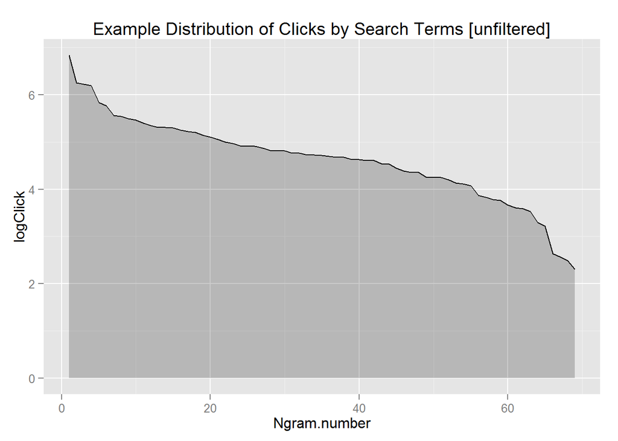

A simple histogram is easy to produce. This example also includes a density plot.

```
## stat_bin: binwidth defaulted to range/30. Use 'binwidth = x' to adjust this.
## stat_bin: binwidth defaulted to range/30. Use 'binwidth = x' to adjust this.
```

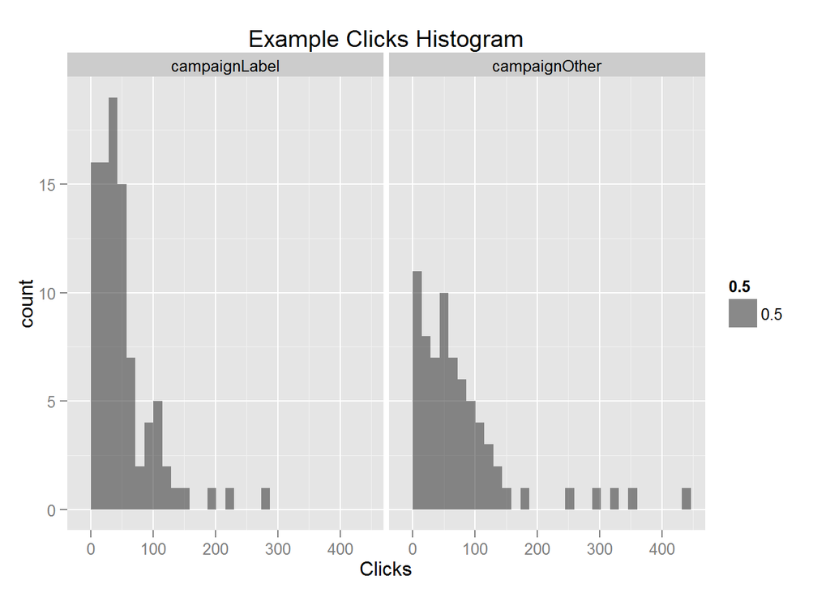

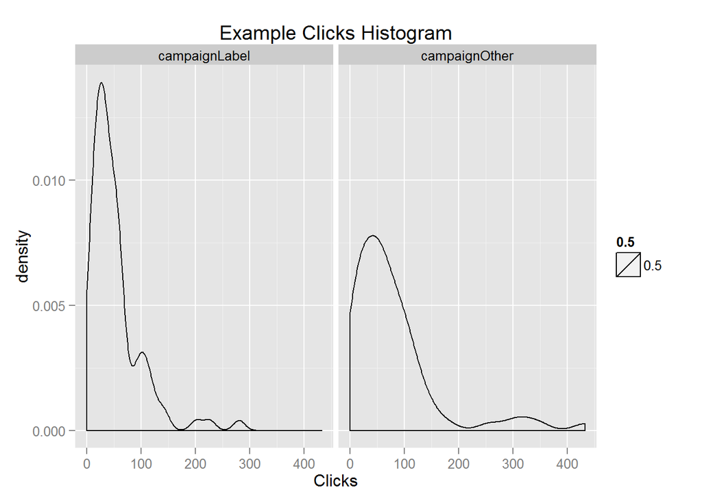

Though for paid search I find that scatter plots are very useful, as generally I am looking for bivariate outliers rather than univariate .

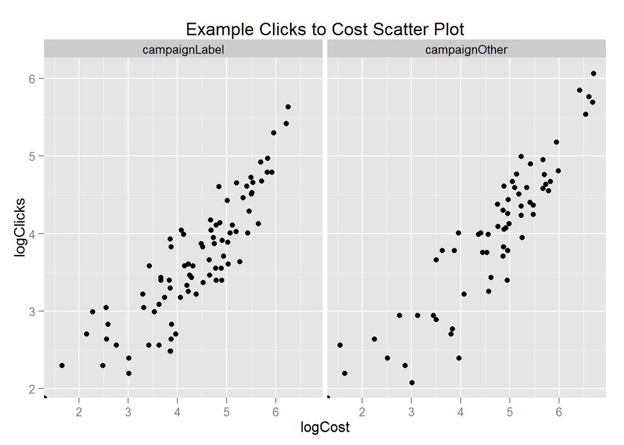

The following is an example that manipulates the labels on the points to highlight those of interest, and leave the plot ‘fairly’ uncluttered.

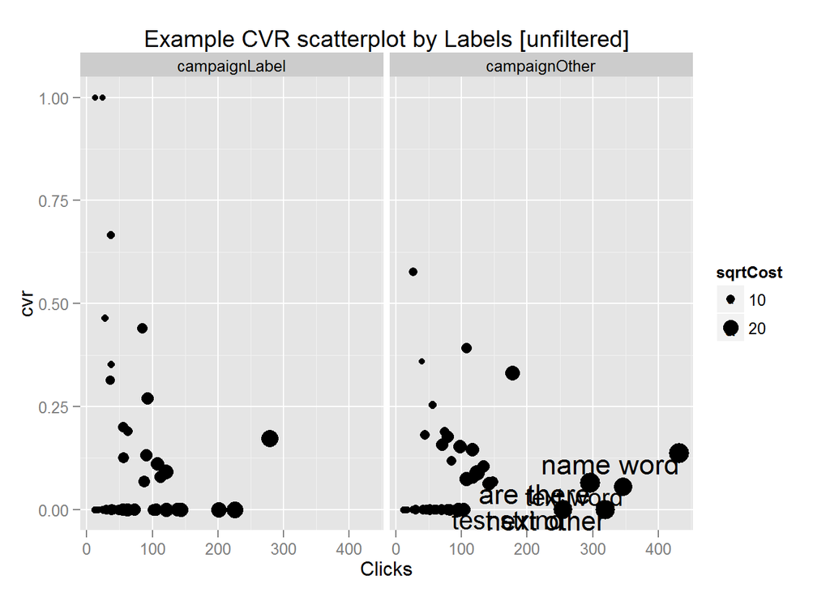

The following table is a simple one looking at the distribution of the CVR per ngram within groups of labels and campaigns. The data is not really appropriate for this, but it is an interesting exercise in looking how the number of observations can affect the error of the mean CVR.

| Campaign | Labels | mcvr | n | mean | sd | se | ci |
| --- | --- | --- | --- | --- | --- | --- | --- |
| Campaign 01 | campaignLabel | 0.13 | 4 | 0.17 | 0.11 | 0.06 | 0.18 |
| Campaign 02 | campaignLabel | 0.24 | 13 | 0.38 | 0.32 | 0.09 | 0.19 |
| Campaign 03 | campaignOther | 0.19 | 5 | 0.28 | 0.19 | 0.09 | 0.24 |
| Campaign 04 | campaignOther | 0.13 | 16 | 0.15 | 0.10 | 0.03 | 0.05 |

Which is then plotted here, where the line through each plot is the group mean.

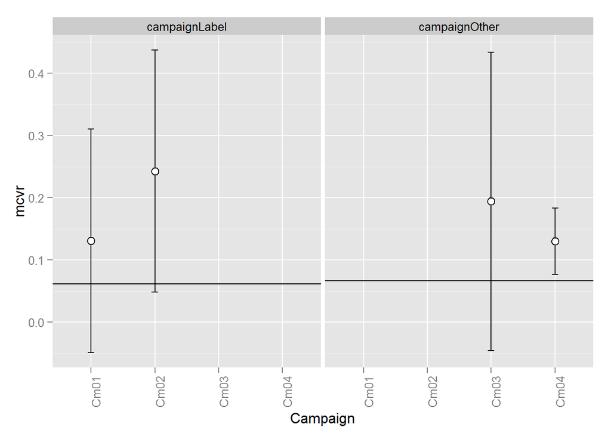

For context here is a plot of clicks to CVR.

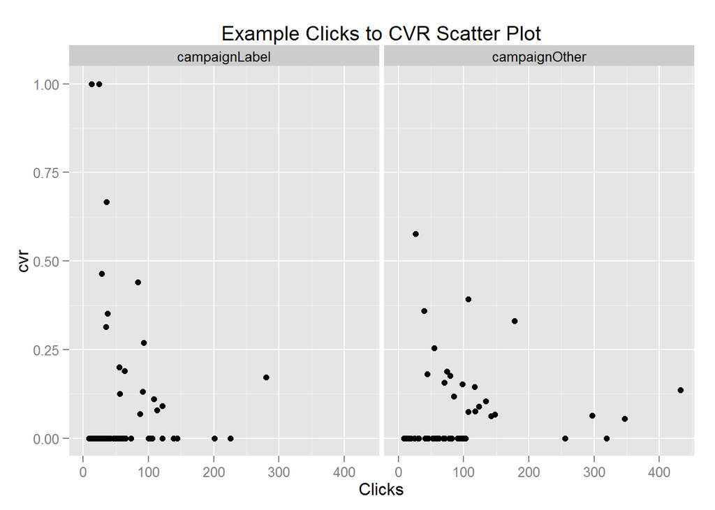

# Extreme Values

There are a few techniques used for testing assumptions for multivariate regression, [Mahalanobis Distance](https://en.wikipedia.org/wiki/Mahalanobis_distance) and [Cook’s Distance](https://en.wikipedia.org/wiki/Cook%27s_distance). The data used here is certainly not appropriate for regression, the two tests mentioned above can be used to identify points that do not exhibit the same relationship between Clicks and Conversions.

The following is a simple check for outliers against the fitted linear model with conversions as an outcome by clicks against campaigns and weighted on cost.

```
##     rstudent unadjusted p-value Bonferonni p
## 161      6.9            1.3e-10      1.9e-08
## 123      6.8            2.4e-10      3.7e-08
## 126     -5.3            3.9e-07      6.0e-05
## 74       4.4            2.3e-05      3.4e-03
```

[output not shown]

The first table is the top ten individual observations by clicks matching to the ngrams identified above. Next is a quick review of the performance of the ngrams identified as outliers by campaign.

| Keyword | Search.term | Impressions | Clicks | Cost | Converted.clicks | cvr |
| --- | --- | --- | --- | --- | --- | --- |
| Keyword 01 | phrase name word uno | 425 | 51 | 131 | 17 | 0.33 |
| Keyword 01 | phrase name word uno | 425 | 51 | 131 | 17 | 0.33 |
| Keyword 05 | next name word uno | 80 | 48 | 99 | 32 | 0.67 |
| Keyword 05 | next name word uno | 80 | 48 | 99 | 32 | 0.67 |
| Keyword 20 | text word do | 91 | 39 | 22 | 0 | 0.00 |
| Keyword 05 | text word test string | 60 | 36 | 74 | 24 | 0.67 |
| Keyword 05 | text word test string | 60 | 36 | 74 | 24 | 0.67 |
| Keyword 12 | name word | 1615 | 34 | 60 | 0 | 0.00 |
| Keyword 33 | next text test string | 34 | 34 | 24 | 0 | 0.00 |
| Keyword 03 | ase name word uno | 64 | 32 | 52 | 0 | 0.00 |

| ngram | Campaign 01 | Campaign 02 | Campaign 03 | Campaign 04 |
| --- | --- | --- | --- | --- |
| name word | 0 | 0 | 55 | 432 |
| next other | 0 | 0 | 0 | 319 |
| test string | 121 | 84 | 44 | 255 |
| text word | 226 | 280 | 74 | 347 |
| word uno | 39 | 24 | 19 | 178 |

| ngram | Campaign 01 | Campaign 02 | Campaign 03 | Campaign 04 |
| --- | --- | --- | --- | --- |
| name word | NA | NA | 0.00 | 0.14 |
| next other | NA | NA | NA | 0.00 |
| test string | 0.09 | 0.44 | 0.00 | 0.00 |
| text word | 0.00 | 0.17 | 0.19 | 0.05 |
| word uno | 0.00 | 1.00 | 0.00 | 0.33 |

There are a number of differebt methods included here for identifying extreme points. The next is a look at the rows returned by Cook’s Distance.

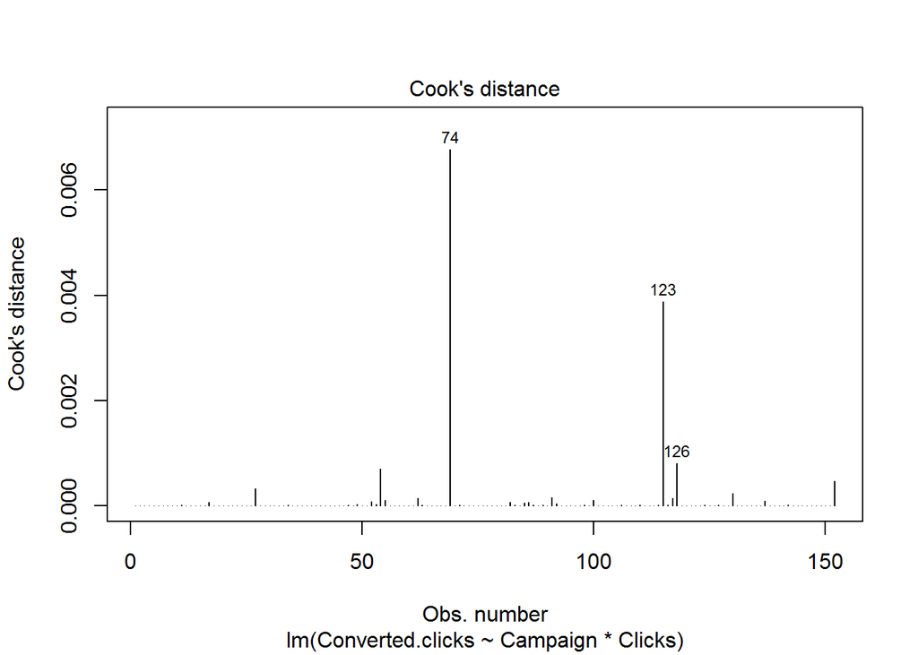

| ngram | Campaign | Labels | Impressions | Cost | Clicks | Converted.clicks | cvr | Observation |
| --- | --- | --- | --- | --- | --- | --- | --- | --- |
| text word | Campaign 01 | campaignLabel | 702 | 493 | 226 | 0 | 0.00 | 28 |
| text word | Campaign 02 | campaignLabel | 1245 | 515 | 280 | 48 | 0.17 | 74 |
| name word | Campaign 04 | campaignOther | 3304 | 807 | 432 | 59 | 0.14 | 123 |

Next is a plot of residuals against the model where the Cook’s distance of each point is displayed as the size of the circle for each point.

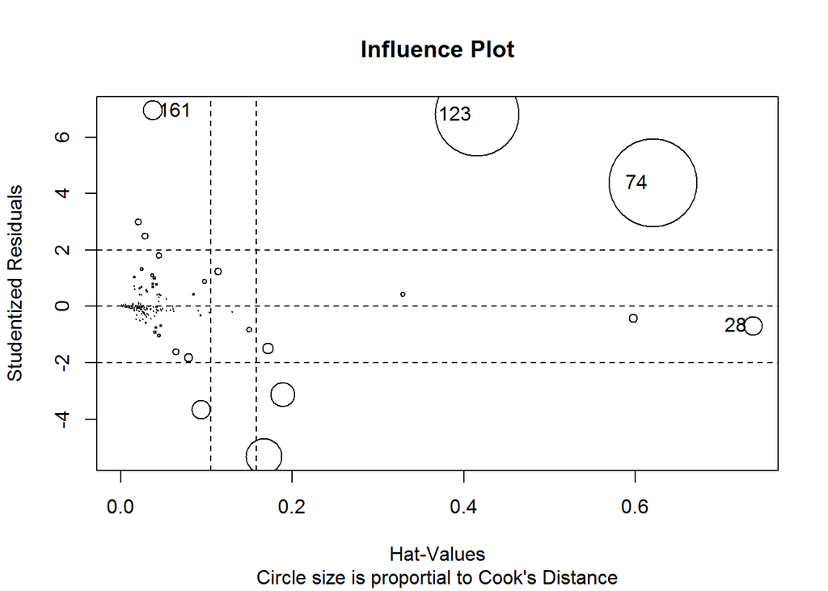

```
##     StudRes   Hat CookD
## 28    -0.68 0.737  0.40
## 74     4.38 0.621  1.87
## 123    6.81 0.415  1.77
## 161    6.94 0.037  0.42
```

[output not shown]

The following are a series of graphs and tables of the relationship between clicks and converted clicks. Both Mahalanobis Disance and Cook’s Distance are included in the tables for each campaign.

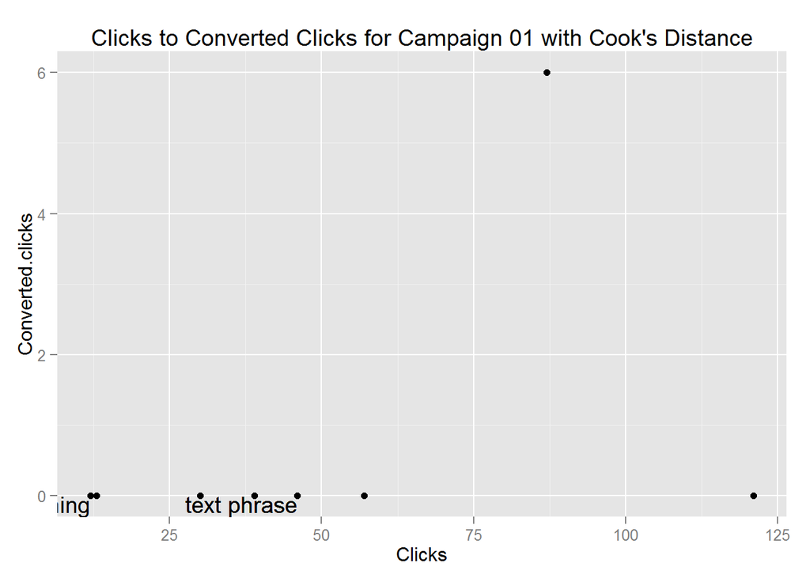

```
##            ngram    Campaign        Labels Impressions Cost Clicks
##  1:  text phrase Campaign 01 campaignLabel         383   48     46
##  2:  text phrase Campaign 01 campaignLabel         383   48     46
##  3:   text thing Campaign 01 campaignLabel          12   47     12
##  4:     ase text Campaign 01 campaignLabel        3097  337    121
##  5: phrase other Campaign 01 campaignLabel          13   16     13
##  6:     text uno Campaign 01 campaignLabel         161   39     30
##  7:     word one Campaign 01 campaignLabel         106   58     57
##  8:     word uno Campaign 01 campaignLabel          39  103     39
##  9:    other are Campaign 01 campaignLabel         207  206     87
## 10:     word uno Campaign 01 campaignLabel          39  103     39
##     Converted.clicks   cvr    m1    d1
##  1:                0 0.000 0.093 3.488
##  2:                0 0.000 0.093 3.135
##  3:                0 0.000 0.742 0.595
##  4:                0 0.000 4.090 0.271
##  5:                0 0.000 0.701 0.176
##  6:                0 0.000 0.207 0.163
##  7:                0 0.000 0.212 0.159
##  8:                0 0.000 0.101 0.057
##  9:                6 0.069 3.724 0.035
## 10:                0 0.000 0.101 0.034
```

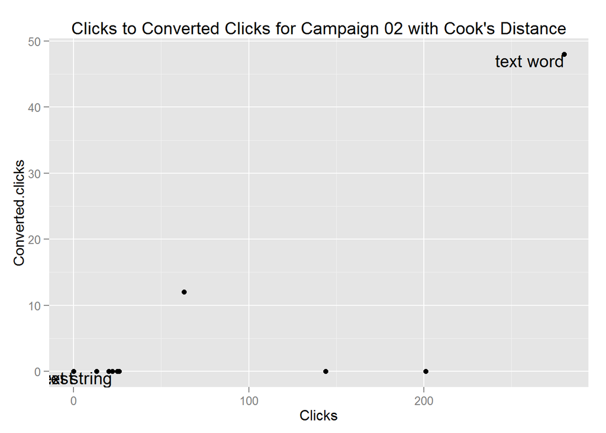

```
##            ngram    Campaign        Labels Impressions Cost Clicks
##  1:  text string Campaign 02 campaignLabel          37   37     22
##  2:    text test Campaign 02 campaignLabel          54    0      0
##  3:    text word Campaign 02 campaignLabel        1245  515    280
##  4:     one text Campaign 02 campaignLabel         941  385    201
##  5: phrase thing Campaign 02 campaignLabel          13   30     13
##  6:     text uno Campaign 02 campaignLabel         670   27     25
##  7:  word string Campaign 02 campaignLabel          46   34     20
##  8:      are one Campaign 02 campaignLabel         327  128     63
##  9:     one word Campaign 02 campaignLabel        1627  340    144
## 10:       are on Campaign 02 campaignLabel        1310   67     26
##     Converted.clicks  cvr    m1    d1
##  1:                0 0.00  0.45 3.488
##  2:                0 0.00  1.04 3.135
##  3:               48 0.17 21.99 0.595
##  4:                0 0.00 10.65 0.271
##  5:                0 0.00  0.64 0.176
##  6:                0 0.00  0.40 0.163
##  7:                0 0.00  0.48 0.159
##  8:               12 0.19  0.38 0.057
##  9:                0 0.00  4.50 0.035
## 10:                0 0.00  0.38 0.034
```

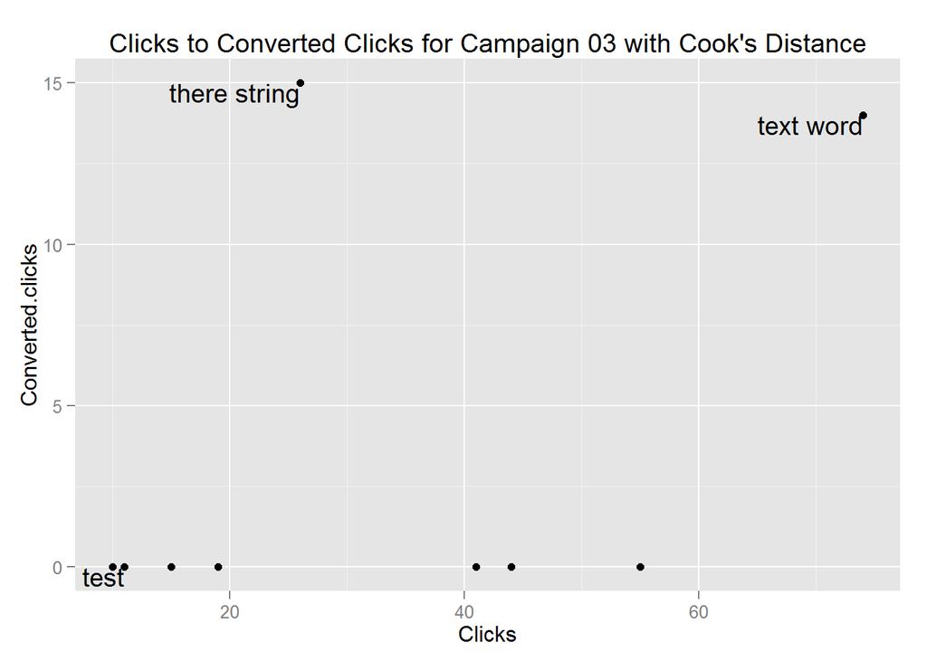

```
##            ngram    Campaign        Labels Impressions Cost Clicks
##  1: there string Campaign 03 campaignOther          26   96     26
##  2:    text test Campaign 03 campaignOther         143   12     11
##  3:    text word Campaign 03 campaignOther         185  128     74
##  4:    name word Campaign 03 campaignOther         722   52     55
##  5:     word dou Campaign 03 campaignOther          15   45     15
##  6:    are there Campaign 03 campaignOther         195  128     41
##  7:     word uno Campaign 03 campaignOther         479   23     19
##  8:  test string Campaign 03 campaignOther         213   37     44
##  9:    other are Campaign 03 campaignOther         195  128     41
## 10:     text uno Campaign 03 campaignOther          10   18     10
##     Converted.clicks  cvr   m1    d1
##  1:               15 0.58 9.11 3.488
##  2:                0 0.00 0.49 3.135
##  3:               14 0.19 3.76 0.595
##  4:                0 0.00 2.17 0.271
##  5:                0 0.00 0.34 0.176
##  6:                0 0.00 0.85 0.163
##  7:                0 0.00 0.25 0.159
##  8:                0 0.00 1.07 0.057
##  9:                0 0.00 0.85 0.035
## 10:                0 0.00 0.53 0.034
```

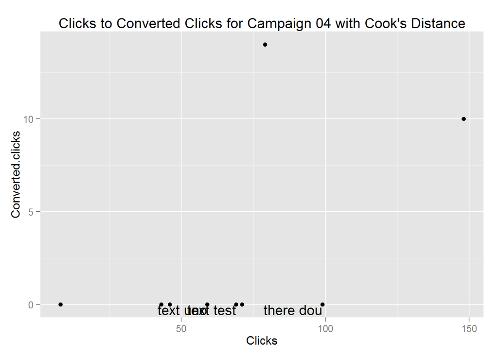

```
##            ngram    Campaign        Labels Impressions Cost Clicks
##  1:    text test Campaign 04 campaignOther          69  185     69
##  2:     text uno Campaign 04 campaignOther         287  136     59
##  3:    there dou Campaign 04 campaignOther         323  162     99
##  4:    next text Campaign 04 campaignOther        1300  186    148
##  5: phrase there Campaign 04 campaignOther         737   92     43
##  6:     text uno Campaign 04 campaignOther         287  136     59
##  7:   word thing Campaign 04 campaignOther           8   20      8
##  8:    ase there Campaign 04 campaignOther         133  238     79
##  9:   next there Campaign 04 campaignOther         165  130     46
## 10:     ase name Campaign 04 campaignOther         177  142     71
##     Converted.clicks   cvr   m1    d1
##  1:                0 0.000 0.28 3.488
##  2:                0 0.000 0.33 3.135
##  3:                0 0.000 0.34 0.595
##  4:               10 0.068 0.23 0.271
##  5:                0 0.000 0.48 0.176
##  6:                0 0.000 0.33 0.163
##  7:                0 0.000 1.11 0.159
##  8:               14 0.177 0.66 0.057
##  9:                0 0.000 0.44 0.035
## 10:                0 0.000 0.27 0.034
```